# HW5 BioStatistic

Bondareva Alina Kirillovna

2024-04-10

# Домашнее задание №5.

## Выполнила Бондарева Алина Кирилловна

**Тема:** построение регрессионных моделей и анализ выживаемости.

**Цель:** научиться пользоваться основными методами регрессионного анализа, разобраться с принципами анализа выживаемости.

**Описание ДЗ**: Для выполнения первых двух заданий мы будем использовать датасет *Breast Cancer Wisconsin*. В колонке `diagnosis` содержится информация об опухоли (`M` = злокачественная, `B` = доброкачественная).

### **Задание 1**

*1. Создайте регрессионную модель, которая бы описывала связь среднего радиуса опухоли и средней площади (а), среднего периметра (б), средней симметричности (в).*

*2. Постройте графики, на которых отразите регрессионную прямую, и прокомментируйте свои находки.*

Сначала давайте загрузим и посмотрим наш датасет:

```r
cancer <- read.csv("C:/Users/bonda/Desktop/МФТИ/2 семестр/Биостатистика/ДЗ5/wisconsin_breast_cancer.csv")

head(cancer)
```

```
##         id diagnosis radius_mean texture_mean perimeter_mean area_mean
## 1   842302         M       17.99        10.38         122.80    1001.0
## 2   842517         M       20.57        17.77         132.90    1326.0
## 3 84300903         M       19.69        21.25         130.00    1203.0
## 4 84348301         M       11.42        20.38          77.58     386.1
## 5 84358402         M       20.29        14.34         135.10    1297.0
## 6   843786         M       12.45        15.70          82.57     477.1
##   smoothness_mean compactness_mean concavity_mean concave.points_mean
## 1         0.11840          0.27760         0.3001             0.14710
## 2         0.08474          0.07864         0.0869             0.07017
## 3         0.10960          0.15990         0.1974             0.12790
## 4         0.14250          0.28390         0.2414             0.10520
## 5         0.10030          0.13280         0.1980             0.10430
## 6         0.12780          0.17000         0.1578             0.08089
##   symmetry_mean fractal_dimension_mean radius_se texture_se perimeter_se
```

[output cut: 34 more lines]

```r
str(cancer)
```

```
## 'data.frame':    569 obs. of  33 variables:
##  $ id                     : int  842302 842517 84300903 84348301 84358402 843786 844359 84458202 844981 84501001 ...
##  $ diagnosis              : chr  "M" "M" "M" "M" ...
##  $ radius_mean            : num  18 20.6 19.7 11.4 20.3 ...
##  $ texture_mean           : num  10.4 17.8 21.2 20.4 14.3 ...
##  $ perimeter_mean         : num  122.8 132.9 130 77.6 135.1 ...
##  $ area_mean              : num  1001 1326 1203 386 1297 ...
##  $ smoothness_mean        : num  0.1184 0.0847 0.1096 0.1425 0.1003 ...
##  $ compactness_mean       : num  0.2776 0.0786 0.1599 0.2839 0.1328 ...
##  $ concavity_mean         : num  0.3001 0.0869 0.1974 0.2414 0.198 ...
##  $ concave.points_mean    : num  0.1471 0.0702 0.1279 0.1052 0.1043 ...
##  $ symmetry_mean          : num  0.242 0.181 0.207 0.26 0.181 ...
##  $ fractal_dimension_mean : num  0.0787 0.0567 0.06 0.0974 0.0588 ...
##  $ radius_se              : num  1.095 0.543 0.746 0.496 0.757 ...
##  $ texture_se             : num  0.905 0.734 0.787 1.156 0.781 ...
```

[output cut: 19 more lines]

Нам нужно построить регрессионную модель, которая бы описывала связь **среднего радиуса опухоли** (`radius_mean`) и: * **средней площади** (`area_mean`); * **среднего периметра** (`perimeter_mean`); * **средней симметричности** (`symmetry_mean`).

Для этого давайте сначала проверим интересующие нас столбцы на пропущенные значения:

```r
# Проверка пропущенных значений
colSums(is.na(cancer[c("radius_mean", "area_mean", "perimeter_mean", "symmetry_mean")]))
```

```
##    radius_mean      area_mean perimeter_mean  symmetry_mean
##              0              0              0              0
```

Мы видим, что пропущенных значений нет. Значит мы можем приступать к работе!

Выдвинем следующие гипотезы:

`Н0` - **Зависимая переменная и фактор не имеют статистически значимой зависимости;** `H1` - **Зависимая переменная и фактор имеют статистически значимую зависимость.**

В медицинских исследованиях обычно используется уровень значимости
$$\alpha = 0.05$$
, что означает, что вероятность отклонить нулевую гипотезу, когда она верна, составляет 5%.

В данной ситуации оправдано использование линейной регрессии, так как все рассматриваемые переменные представлены в форме непрерывных числовых данных.

Построим первую линейную модель регрессии среднего радиуса опухоли и средней площади:

```r
# Создание линейной регрессионной модели для среднего радиуса опухоли и средней площади
model1_area <- lm(radius_mean ~ area_mean, data = cancer)
summary(model1_area)
```

```
##
## Call:
## lm(formula = radius_mean ~ area_mean, data = cancer)
##
## Residuals:
##     Min      1Q  Median      3Q     Max
## -4.9604 -0.1801  0.1479  0.3600  0.7788
##
## Coefficients:
##              Estimate Std. Error t value Pr(>|t|)
## (Intercept) 7.652e+00  4.955e-02   154.4   <2e-16 ***
## area_mean   9.887e-03  6.666e-05   148.3   <2e-16 ***
## ---
## Signif. codes:  0 '***' 0.001 '**' 0.01 '*' 0.05 '.' 0.1 ' ' 1
##
## Residual standard error: 0.5591 on 567 degrees of freedom
## Multiple R-squared:  0.9749, Adjusted R-squared:  0.9748
## F-statistic: 2.2e+04 on 1 and 567 DF,  p-value: < 2.2e-16
```

Интерпретация результатов модели1:

**Распределение остатков (Residuals)**

**Коэффициенты предикторов (Estimate)**

**Значение коэффициента интерсепта (Intercept)**

- `Coefficients Intercept` - *Значение радиуса опухоли при нулевом значении факторов*: 7.652 - это гипотетическое значение среднего радиуса, если средняя площадь была бы равна 0, что не имеет отношения реальности, но необходимо для математической формулировки модели.

**Статистическая значимость**

- `P-value` для обоих коэффициентов (<2e-16): Указывает на то, что связь между средним радиусом и средней площадью статистически значима.

**Общая статистика модели**

- `F-статистика`: 2.2e+04, что в сочетании с `p-value` модели (<2.2e-16) подчеркивает, что модель в целом статистически значима.
- `Residual standart error` - *Остаточная стандартная ошибка*: 0.5591, что относительно низко и говорит о хорошем качестве подгонки модели.
- `Adjusted R-squared` - *Скорректированный коэффициент детерминации*: 0.9748, показывает, что модель объясняет 97.48% вариации среднего радиуса опухоли. Это указывает на высокую предсказательную способность модели, хотя и это может быть признаком переобучения.

Данная модель показывает, что **средняя площадь `area_mean` опухоли является важным предиктором среднего радиуса опухоли `radius_mean`**, с высокой степенью статистической значимости и предсказательной способностью. Однако, важно проверить выполнение основных предположений линейной регрессии, включая нормальность распределения остатков и гомоскедастичность, что мы дальше и сделаем.

Проведем сначала визуальную оценку линейной зависимости переменной и одного из наших факторов:

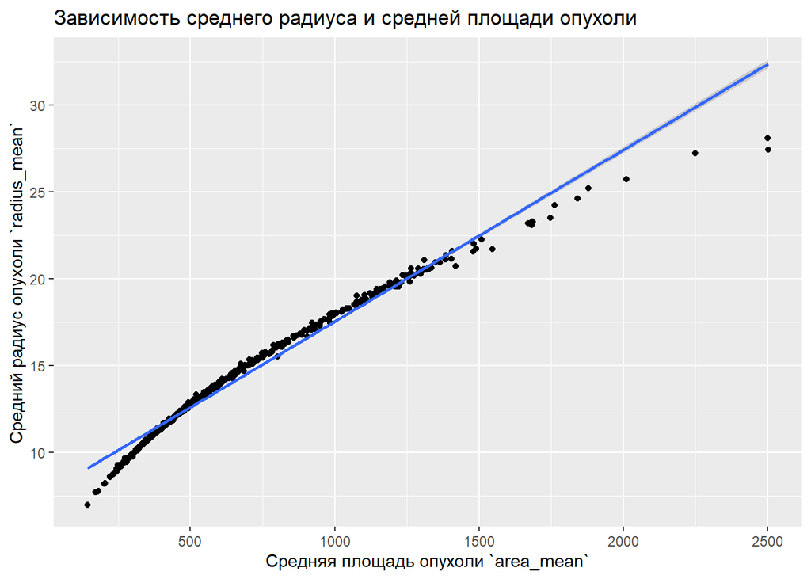

```r
# Визуальная оценка линейности зависимости
ggplot(cancer, aes(x = area_mean, y = radius_mean)) +
geom_point() +
labs(title = "Зависимость среднего радиуса и средней площади опухоли",
    x = "Средняя площадь опухоли `area_mean`",
    y = "Средний радиус опухоли `radius_mean`") +
geom_smooth(method = "lm")
```

Проверим теперь нормальность распределения остатков.

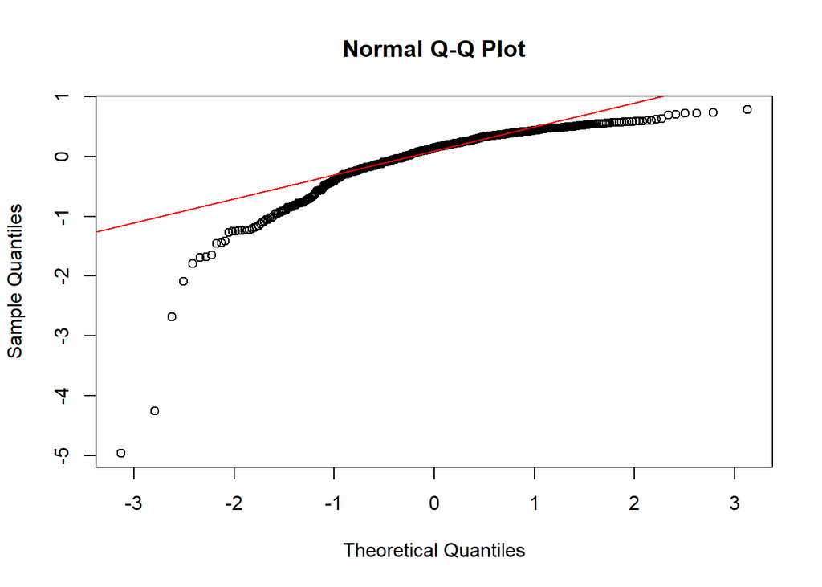

```r
# Визуальная оценка нормальности распределения остатков
qqnorm(residuals(model1_area))
qqline(residuals(model1_area), col = "red")
```

```r
# Оценка нормальности распределения остатков с помощью теста Шапиро-Уилка
shapiro.test(residuals(model1_area))
```

```
##
##  Shapiro-Wilk normality test
##
## data:  residuals(model1_area)
## W = 0.78456, p-value < 2.2e-16
```

На графике Q_Q Plot точки (остатки) демонстрируют незначительные отклонения и, можно сказать, укладываются в заданные границы, в то время как в левой части графика наблюдаются значительные отклонения от линии.

Тест Шапиро-Уилка также показывает нам не нормальное распределение остатков, поскольку `p-value` значительно меньше
$$\alpha=0.05$$
(p-value < 2.2e-16). Это означает, что нулевую гипотезу о нормальности распределения остатков следует отвергнуть и принять альтернативную гипотезу.

Проверим еще гомоскедастичность остатков:

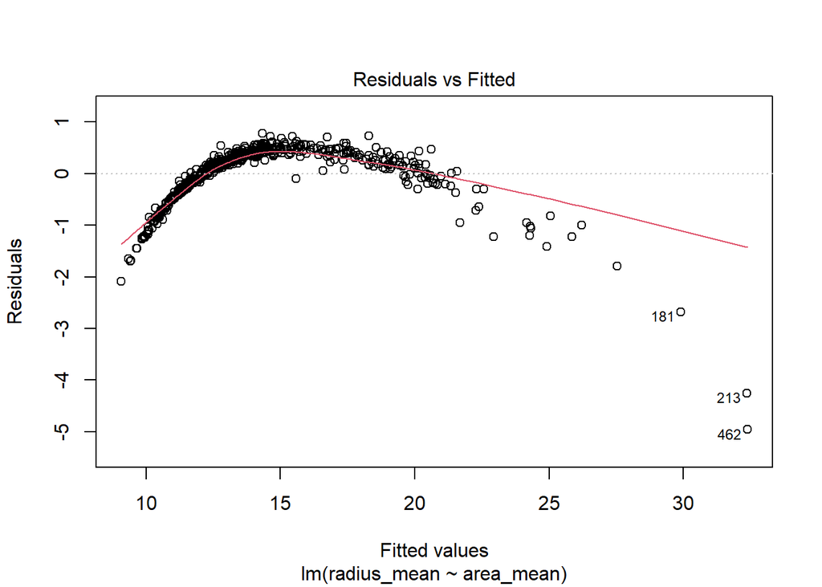

```r
# Проверка гомоскедастически остатков
plot(model1_area, which = 1)
```

Мы видим явные признаки неоднородности в распределении остатков, проявляющиеся в том, что в одних частях графика точки сгущены, а в других их плотность заметно ниже. Это указывает на потенциальное нарушение предпосылки о гомоскедастичности, согласно которой дисперсии остатков должны быть одинаковыми на всех уровнях независимой переменно — можно сделать **вывод, что зависимость между рассматриваемыми переменными, возможно, не полностью линейна или что в модели могут быть неучтенные факторы, вызывающие изменчивость ошибок.**

Теперь сделаем то же самое со средним периметром `perimeter_mean`

```r
# Создание линейной регрессионной модели для среднего радиуса опухоли и среднего периметра опухли
model2_perimeter <- lm(radius_mean ~ perimeter_mean, data = cancer)
summary(model2_perimeter)
```

```
##
## Call:
## lm(formula = radius_mean ~ perimeter_mean, data = cancer)
##
## Residuals:
##      Min       1Q   Median       3Q      Max
## -1.43367 -0.10445  0.02596  0.14652  0.60550
##
## Coefficients:
##                 Estimate Std. Error t value Pr(>|t|)
## (Intercept)    0.8177520  0.0379227   21.56   <2e-16 ***
## perimeter_mean 0.1447176  0.0003987  362.99   <2e-16 ***
## ---
## Signif. codes:  0 '***' 0.001 '**' 0.01 '*' 0.05 '.' 0.1 ' ' 1
##
## Residual standard error: 0.2309 on 567 degrees of freedom
## Multiple R-squared:  0.9957, Adjusted R-squared:  0.9957
## F-statistic: 1.318e+05 on 1 and 567 DF,  p-value: < 2.2e-16
```

Интерпретация результатов модели2:

**Распределение остатков (Residuals)**

- `Минимальное значение остатков (Min)`: -1.43367, отражающее наибольшее отклонение предсказаний модели вниз.
- `Максимальное значение остатков (Max)`: 0.60550, показывающее максимальное отклонение предсказаний вверх.
- `Медиана остатков (Median)`: 0.02596, что является близким к нулю значением, указывающим на отсутствие систематической ошибки в предсказаниях модели.
- `Интерквартильный размах (1Q-3Q)`: -0.10445 (первый квартиль) и 0.14652 (третий квартиль), показывающие диапазон, в котором находится большинство остатков, указывая на относительную устойчивость модели.

**Коэффициенты предикторов (Estimate)**

- `Coefficients Estimate area_mean` - Изменение среднего радиуса опухоли при увеличении среднего периметра на единицу: На 0.1447176. Это указывает на сильную положительную связь между средним периметром и средним радиусом опухоли.

**Значение коэффициента интерсепта (Intercept)**

- `Coefficients Intercept` - Значение среднего радиуса опухоли при нулевом значении среднего периметра: 0.8177520. Хотя на практике средний периметр не может быть нулевым, это значение служит отправной точкой для предсказаний модели.

**Статистическая значимость**

- `P-value` для коэффициентов (<2e-16): Статистически значимая связь между средним радиусом и средним периметром опухоли.

**Общая статистика модели**

- `F-статистика`: 1.318e+05 на 1 и 567 степенях свободы, вместе с p-value (<2.2e-16) подтверждает статистическую значимость модели.
- `Residual standart error` - Остаточная стандартная ошибка: 0.2309, указывая на точность предсказаний модели.
- `Adjusted R-squared` - Скорректированный коэффициент детерминации: 0.9957, что означает, что модель объясняет 99.57% вариации среднего радиуса опухоли. Это свидетельствует о высокой предсказательной способности модели, но также поднимает вопросы о возможном переобучении.

Эта модель демонстрирует, что средний периметр опухоли является мощным предиктором среднего радиуса опухоли с высокой степенью статистической значимости и предсказательной способности.

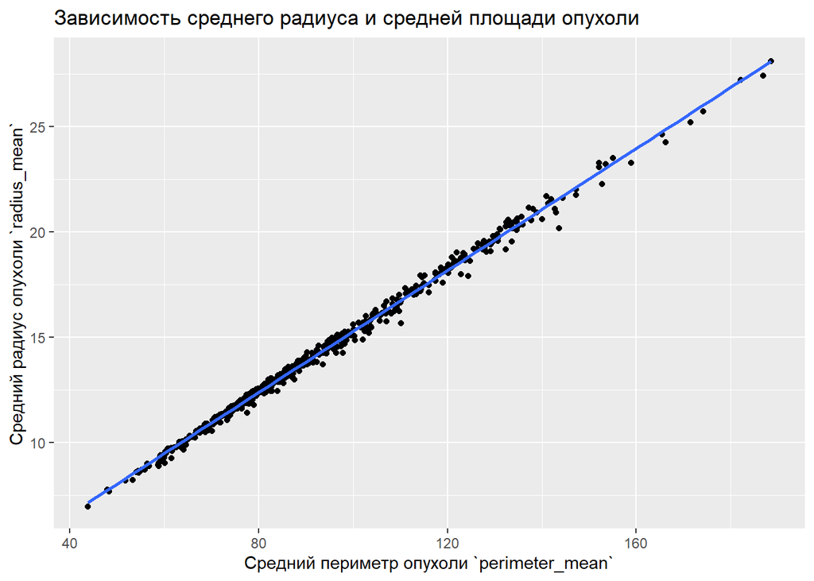

```r
# Визуальная оценка линейности зависимости
ggplot(cancer, aes(x = perimeter_mean, y = radius_mean)) +
geom_point() +
labs(title = "Зависимость среднего радиуса и средней площади опухоли",
    x = "Средний периметр опухоли `perimeter_mean`",
    y = "Средний радиус опухоли `radius_mean`") +
geom_smooth(method = "lm")
```

На графике видно, что фактор имеет линейную зависимость с перемененной радиуса опхуоли. Проверим теперь нормальность распределения остатков.

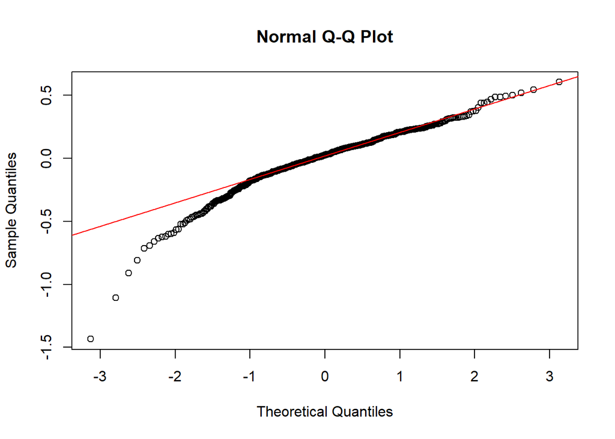

```r
# Визуальная оценка нормальности распределения остатков
qqnorm(residuals(model2_perimeter))
qqline(residuals(model2_perimeter), col = "red")
```

Здесь мы видим похожую ситуацию с прошлым фактором средней площади опухоли, в левой части графика есть существенные отклонения остатков. Проведем тест Шапиро-Уилка:

```r
# Оценка нормальности распределения остатков с помощью теста Шапиро-Уилка
shapiro.test(residuals(model2_perimeter))
```

```
##
##  Shapiro-Wilk normality test
##
## data:  residuals(model2_perimeter)
## W = 0.93901, p-value = 1.641e-14
```

Тест Шапиро-Уилка также выявляет отсутствие нормальности в распределении остатков, так как p-value значительно меньше порогового уровня значимости
$$\alpha=0.05$$
(p-value = 1.641e-14). Это указывает на то, что мы отвергаем нулевую гипотезу о нормальности распределения остатков и принимаем альтернативную гипотезу о том, что распределение остатков не соответствует нормальному распределению.

Проверим еще гомоскедастичность остатков:

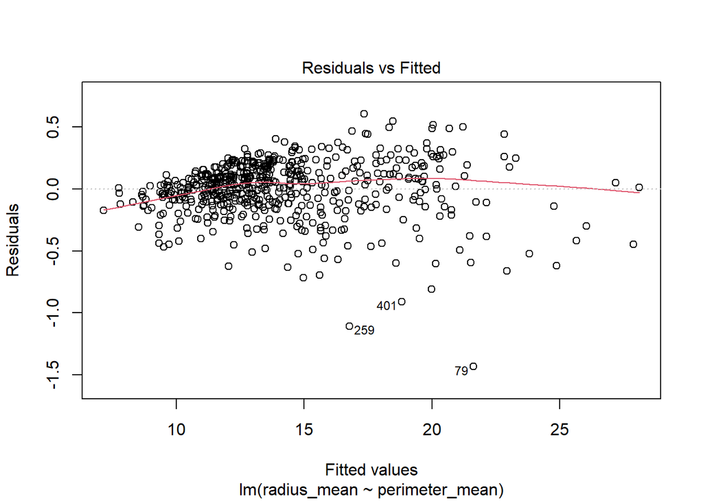

```r
# Проверка гомоскедастически остатков
plot(model2_perimeter, which = 1)
```

На данном графике точки кажутся более разбросанными по мере увеличения фитированных значений, что может указывать на потенциальную гетероскедастичность — изменение дисперсии остатков в зависимости от уровня предсказанных значений. Это наблюдение предполагает, что в модели могут быть неучтенные нелинейные связи или другие факторы, влияющие на изменчивость ошибок.

Теперь сделаем то же самое со средней семетричности `symmetry_mean`

```r
# Создание линейной регрессионной модели для среднего радиуса опухоли и средней площади
model3_symmetry <- lm(radius_mean ~ symmetry_mean, data = cancer)
summary(model3_symmetry)
```

```
##
## Call:
## lm(formula = radius_mean ~ symmetry_mean, data = cancer)
##
## Residuals:
##     Min      1Q  Median      3Q     Max
## -7.3711 -2.4426 -0.5862  1.5744 14.2934
##
## Coefficients:
##               Estimate Std. Error t value Pr(>|t|)
## (Intercept)    10.6867     0.9783  10.924  < 2e-16 ***
## symmetry_mean  18.9918     5.3393   3.557 0.000406 ***
## ---
## Signif. codes:  0 '***' 0.001 '**' 0.01 '*' 0.05 '.' 0.1 ' ' 1
##
## Residual standard error: 3.488 on 567 degrees of freedom
## Multiple R-squared:  0.02183,    Adjusted R-squared:  0.0201
## F-statistic: 12.65 on 1 and 567 DF,  p-value: 0.0004065
```

Интерпретация результатов модели3:

**Распределение остатков (Residuals)**

- `Минимальное значение остатков (Min)`: -7.3711, что указывает на значительное отклонение предсказаний модели вниз.
- `Максимальное значение остатков (Max)`: 14.2934, показывает сильное отклонение предсказаний вверх.
- `Медиана остатков (Median)`: -0.5862, демонстрирует небольшую наклонность распределения остатков в сторону отрицательных значений.
- `Интерквартильный размах (1Q-3Q)`: -2.4426 (первый квартиль) и 1.5744 (третий квартиль), обозначает широкий разброс остатков, что может свидетельствовать о потенциальной нестабильности модели.

**Коэффициенты предикторов (Estimate)**

- `Coefficients Estimate symmetry_mean` - Изменение среднего радиуса опухоли при увеличении среднего периметра на единицу: На 18.9918. Это показывает, что существует положительная связь между симметрией опухоли и средним радиусом опухоли, хотя основываясь на значении R-квадрата, эта связь может быть не столь сильной.

**Значение коэффициента интерсепта (Intercept)**

- `Coefficients Intercept` - Значение среднего радиуса опухоли при нулевом значении `symmetry_mean`: 10.6867. Это представляет собой ожидаемое значение среднего радиуса опухоли, когда средняя симметрия равна нулю.

**Статистическая значимость**

- `P-value` для коэффициента `symmetry_mean` (0.000406): Свидетельствует о статистически значимой связи между симметрией и средним радиусом опухоли, хотя сила связи может быть невелика.

**Общая статистика модели**

- `F-статистика`: 12.65 на 1 и 567 степенях свободы, показывает, что модель статистически значима.
- `Residual standart error` - Остаточная стандартная ошибка: 3.488, указывает на большую изменчивость остатков, что может влиять на точность предсказаний модели.
- `Adjusted R-squared` - Скорректированный коэффициент детерминации: 0.0201, показывает, что модель объясняет только около 2.01% вариации среднего радиуса опухоли, что свидетельствует о слабой предсказательной способности этой модели.

Эта модель показывает, что хотя средняя симметрия опухоли статистически значимо влияет на средний радиус, она объясняет лишь небольшую часть изменчивости радиуса опухоли. Это может указывать на необходимость поиска других, более мощных предикторов или на сложность взаимоотношений в данных, которые не могут быть адекватно описаны простой линейной моделью.

### **Задание 2**

*Пусть колонка с диагнозом принимает следующие значения: злокачественная опухоль — 1, а доброкачественная — 0. Постройте модель, которая бы прогнозировала вероятность возникновения злокачественной опухоли от:* * *среднего радиуса* (`radius_mean`); * *средней площади* (`area_mean`); * *средней текстуры* (`texture_mean`).

*Постройте графики. Создайте модель, которая бы прогнозировала вероятность возникновения злокачественной опухоли от всех трех перечисленных факторов.*

Сначала нам необходимо заменить бинарные значения в колонке `diagnosis` на факториальные 1 - злокачественная опухль, 0 - доброкачественная опухль:

```r
# Заменим значения в колонке diagnosis на бинарные значения 1 и 0
cancer$diagnosis <- ifelse(cancer$diagnosis == 'M', 1, 0)
```

Теперь мы можем построить модель логистической регрессии, которая будет прогнозировать вероятность возникновения опухли:

```r
model4_diagnosis <- glm(diagnosis ~ radius_mean + area_mean + texture_mean, data = cancer, family = 'binomial')
summary(model4_diagnosis)
```

```
##
## Call:
## glm(formula = diagnosis ~ radius_mean + area_mean + texture_mean,
##     family = "binomial", data = cancer)
##
## Coefficients:
##              Estimate Std. Error z value Pr(>|z|)
## (Intercept)  -9.48796    6.88503  -1.378    0.168
## radius_mean  -0.38523    0.95524  -0.403    0.687
## area_mean     0.01636    0.01100   1.487    0.137
## texture_mean  0.20917    0.03714   5.632 1.78e-08 ***
## ---
## Signif. codes:  0 '***' 0.001 '**' 0.01 '*' 0.05 '.' 0.1 ' ' 1
##
## (Dispersion parameter for binomial family taken to be 1)
##
##     Null deviance: 751.44  on 568  degrees of freedom
## Residual deviance: 288.81  on 565  degrees of freedom
## AIC: 296.81
##
## Number of Fisher Scoring iterations: 7
```

Интерпретация результатов модели4:

**Коэффициенты предикторов (Estimate)**

**Общий вывод:** модель не показывает убедительной статистической значимости для всех предикторов, кроме среднего значения текстуры. Следовательно, необходимо дополнительно оценить модель, ее предикторы и рассмотреть возможные проблемы с сходимостью алгоритма для обеспечения надежных результатов.

Чтобы улучшить понимание влияния предикторов в моей модели логистической регрессии, следует экспоненцировать коэффициенты модели:

```r
exp(coefficients(model4_diagnosis))
```

```
##  (Intercept)  radius_mean    area_mean texture_mean
## 7.575823e-05 6.802975e-01 1.016495e+00 1.232654e+00
```

После этого преобразования коэффициентов (и учитывая статистическую значимость), мы можем сделать вывод, что фактор средней текстуры опухоли некоторым обрвзом увеличивает шансы на диагностику злокачественной опухоли в по сравнению с доброкачественной. Влияние других факторов, таких как средний радиус и площадь, на диагноз оказалось статистически не значимыми.

В контексте этой задачи проверка предположений логистической регрессии, таких как отсутствие мультиколлинеарности между предикторами, линейность связи между предикторами и логарифмом шансов, а также исключение экстремальных выбросов, не проводилась, так как это не было в условии задачи.

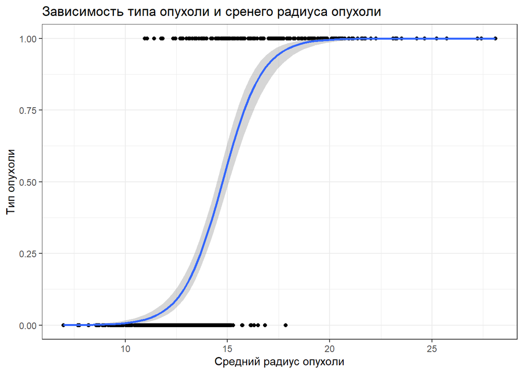

```r
# Визуализация кривой логистической регрессии
ggplot(cancer, aes(x = radius_mean, y = diagnosis)) +
geom_point() +
  labs(title = "Зависимость типа опухоли и сренего радиуса опухоли",
    x = "Средний радиус опухоли",
    y = "Тип опухоли") +
  geom_smooth(method = "glm",
              method.args = list(family = "binomial")) +
theme_bw()
```

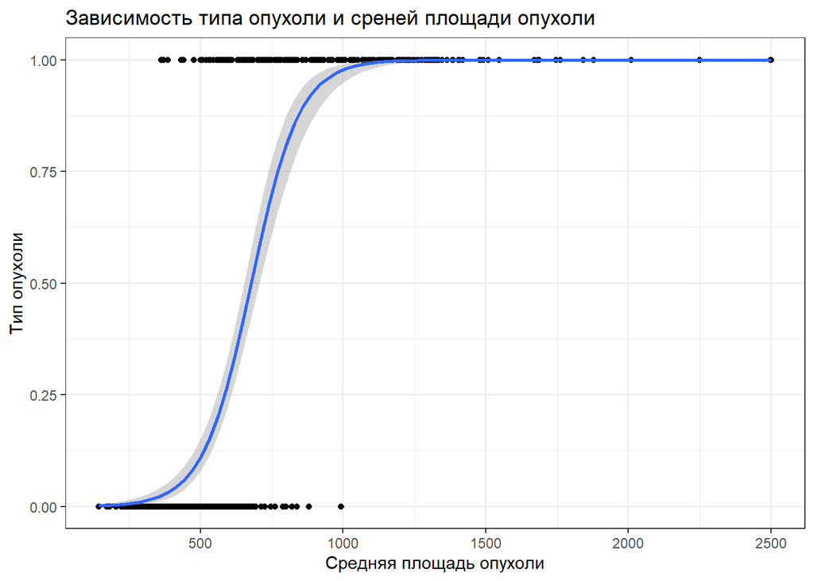

```r
ggplot(cancer, aes(x = area_mean, y = diagnosis)) +
geom_point() +
  labs(title = "Зависимость типа опухоли и среней площади опухоли",
    x = "Средняя площадь опухоли",
    y = "Тип опухоли") +
  geom_smooth(method = "glm",
              method.args = list(family = "binomial")) +
theme_bw()
```

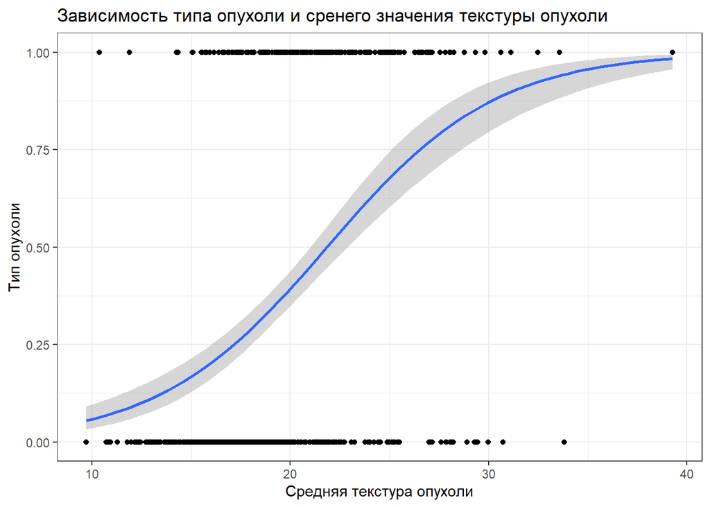

```r
ggplot(cancer, aes(x = texture_mean, y = diagnosis)) +
geom_point() +
  labs(title = "Зависимость типа опухоли и сренего значения текстуры опухоли",
    x = "Средняя текстура опухоли",
    y = "Тип опухоли") +
  geom_smooth(method = "glm",
              method.args = list(family = "binomial")) +
theme_bw()
```

### **Задание 3**

Для выполнения этого задания вам понадобится датасет `lung`, который встроен в пакет `survival`.

Датасет содержит следующий набор переменных:

- `inst`: код учреждения;
- `time`: время выживаемости в днях;
- `status`: 1 = цензурирование, 2 = смерть;
- `age`: возраст в годах;
- `sex`: мужской = 1, женский = 2;
- `ph.ecog`: шкала опросника ECOG (оценку проводит врач). 0 = отсутствие симптомов, 1= симптомы есть, но пациент наблюдается амбулаторно, 2 = меньше половины дня пациент вынужден проводить в постели, 3 = больше половины дня нуждается в отдыхе лежа, но не прикован к постели, 4 = прикован к постели;
- `ph.karno`: шкала Карновского (от 0 до 100, от худшего к лучшему) по оценке врача;
- `pat.karno`: шкала Карновского (от 0 до 100, от худшего к лучшему) по оценке пациента;
- `meal.cal`: калории потребляемой пищи;
- `wt.loss`: потеря веса за последние полгода.
1. Создайте переменную `event`, в которой отразите наличие или отсутствие (1 или 0) интересующего события — смерти пациента.
2. Изучите работу функций `Surv()`, `survfit()` и `ggsurvplot()`: 2.1. Постройте кривые выживаемости в зависимости от пола (на одном графике должны получиться две кривые для каждого пола и таблица числа пациентов, подверженных риску (at risk) под ним). Поясните получившееся значение p-value для лог-рангового теста и опишите наблюдаемые результаты. 2.2. Постройте график кумулятивной функции рисков (**cumulative hazard function**) для пола. Проинтерпретируйте график.

2.3. С помощью функции `coxph()` постройте регрессию Кокса и оцените влияние пола на выживаемость. Что вы можете сказать о полученных результатах?

Сначала инициализируем датасет из пакета:

```r
data_lung <- survival::lung
head(lung)
```

```
##   inst time status age sex ph.ecog ph.karno pat.karno meal.cal wt.loss
## 1    3  306      2  74   1       1       90       100     1175      NA
## 2    3  455      2  68   1       0       90        90     1225      15
## 3    3 1010      1  56   1       0       90        90       NA      15
## 4    5  210      2  57   1       1       90        60     1150      11
## 5    1  883      2  60   1       0      100        90       NA       0
## 6   12 1022      1  74   1       1       50        80      513       0
```

Создадим переменную `event`, в которой отразите наличие или отсутствие (1 или 0) интересующего события — смерти пациента:

```r
lung$event <- ifelse(lung$status == 2,1,0)
head(lung)
```

```
##   inst time status age sex ph.ecog ph.karno pat.karno meal.cal wt.loss event
## 1    3  306      2  74   1       1       90       100     1175      NA     1
## 2    3  455      2  68   1       0       90        90     1225      15     1
## 3    3 1010      1  56   1       0       90        90       NA      15     0
## 4    5  210      2  57   1       1       90        60     1150      11     1
## 5    1  883      2  60   1       0      100        90       NA       0     1
## 6   12 1022      1  74   1       1       50        80      513       0     0
```

Создадим выборку только тех пациентов, которые умерли - достигли целевого события:

```r
data1_lung <- filter(data_lung,lung$event == 1)
head(data1_lung)
```

```
##   inst time status age sex ph.ecog ph.karno pat.karno meal.cal wt.loss
## 1    3  306      2  74   1       1       90       100     1175      NA
## 2    3  455      2  68   1       0       90        90     1225      15
## 4    5  210      2  57   1       1       90        60     1150      11
## 5    1  883      2  60   1       0      100        90       NA       0
## 7    7  310      2  68   2       2       70        60      384      10
## 8   11  361      2  71   2       2       60        80      538       1
```

Изучим работу функций Surv(), survfit() и ggsurvplot():

Построим кривые выживаемости в зависимости от пола (на одном графике должны получиться две кривые для каждого пола и таблица числа пациентов, подверженных риску (at risk) под ним).

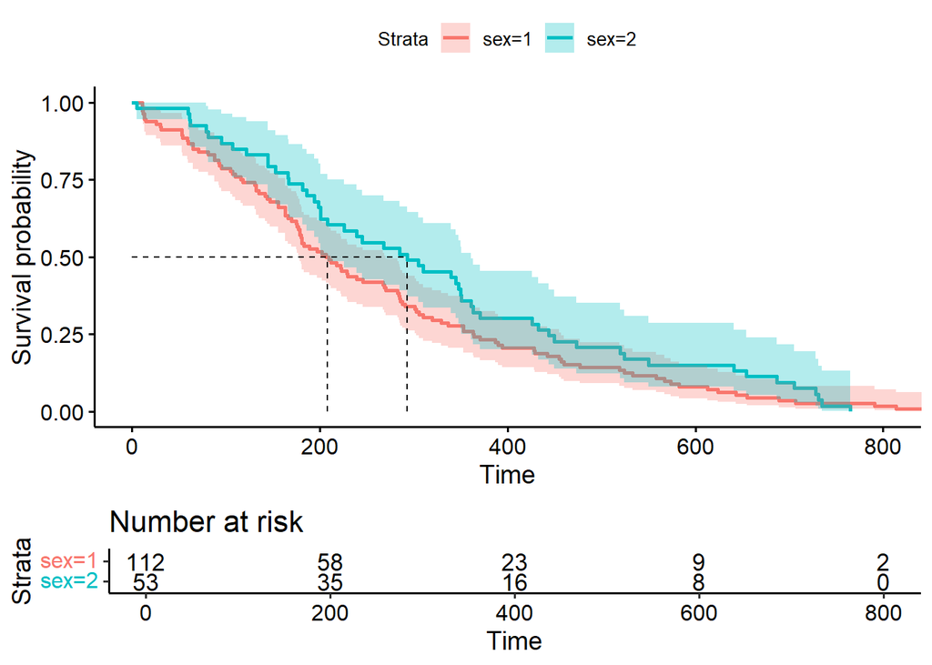

```r
# График кривых выживаемости в зависимости от пола
survfit_func <- survfit(Surv(time, status) ~ sex, data = data1_lung)

ggsurvplot(survfit_func, conf.int = TRUE, surv.median.line = 'hv', risk.table = TRUE)
```

График показывает процент выживших пациентов в течение времени. Доверительные интервалы для мужчин и женщин перекрываются, и кривые выживаемости пересекаются, что может указывать на отсутствие значительных различий в выживаемости между полами.

Установим порог статистической значимости alpha в 0.05, как и раньше, и выдвинем следующие гипотезы:

- `Н0` - нет разницы в выживаемости между группами полов.
- `Н1` - разница в выживаемости между полами есть.

Попробуем провести Лонг-ранг тест, который проводится для сравнения кривых выживаемости между различными группами, в данном случае, между мужчинами и женщинами. Лог-ранг тест позволяет оценить, есть ли статистически значимые различия в выживаемости пациентов этих двух групп.

```r
# Лог-ранг тест
survdiff(Surv(time, status) ~ sex, data = data1_lung)
```

```
## Call:
## survdiff(formula = Surv(time, status) ~ sex, data = data1_lung)
##
##         N Observed Expected (O-E)^2/E (O-E)^2/V
## sex=1 112      112    102.8     0.824      2.24
## sex=2  53       53     62.2     1.362      2.24
##
##  Chisq= 2.2  on 1 degrees of freedom, p= 0.1
```

Интерпретация Лонг-ранг теста:

В контексте задачи это может означать, что пол не имеет значимого влияния на выживаемость пациентов с раком легких в данной выборке.

Теперь построим график кумулятивной функции рисков (`cumulative hazard function`) для пола и проинтерпретируем его.

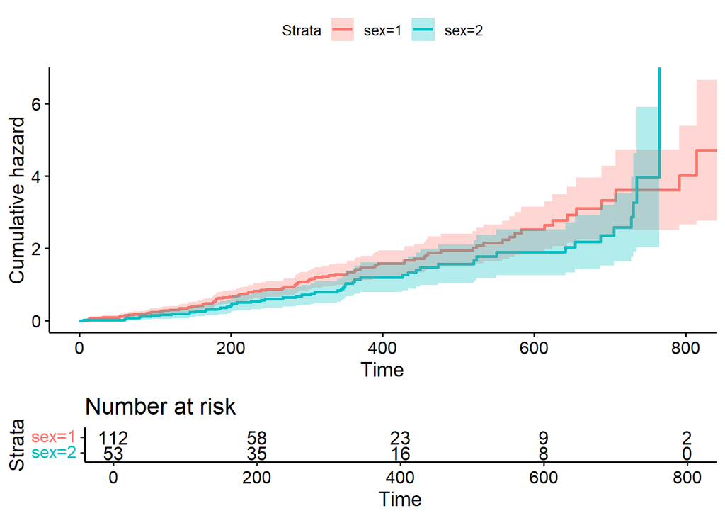

```r
# График кумулятивной функции рисков по полу
ggsurvplot(survfit_func, fun = "cumhaz", conf.int = TRUE, risk.table = TRUE)
```

График кумулятивной функции рисков демонстрирует изменение вероятности наступления события со временем. По горизонтальной оси указано время, по вертикальной — кумулятивный риск.

Из графика видно, что доверительные интервалы для обеих групп частично перекрываются, а их кривые риска в некоторых точках пересекаются. Это указывает на то, что различия в риске между мужчинами и женщинами статистически не значимы.

Общие выводы из результатов регрессии Кокса: